# Municipal Streamflow Regime Classification: Diagnostic Engine & Watershed Assessment

# 5. Diagnostic Hydrograph Visualizations

## 5.1 Day-of-Year Hydrograph Envelopes & Demarcation Thresholds

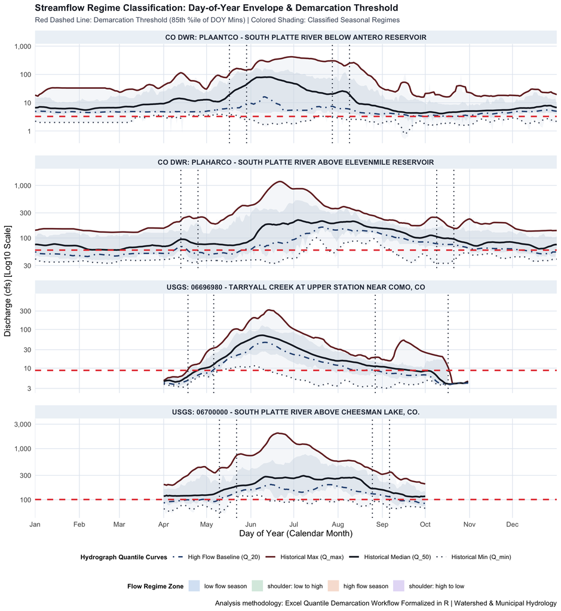

```r
plot_regime_envelope(
  doy_classified = regime_diagnostics$doy_envelopes,
  boundaries = regime_diagnostics$boundaries,
  thresholds = regime_diagnostics$thresholds,
  log_scale = TRUE
)
```

## 5.2 Multi-Year Daily Time Series Colored by Regime

The plot below shows the continuous daily discharge time series for the recent 2018–2023 period, colored by classified flow regime:

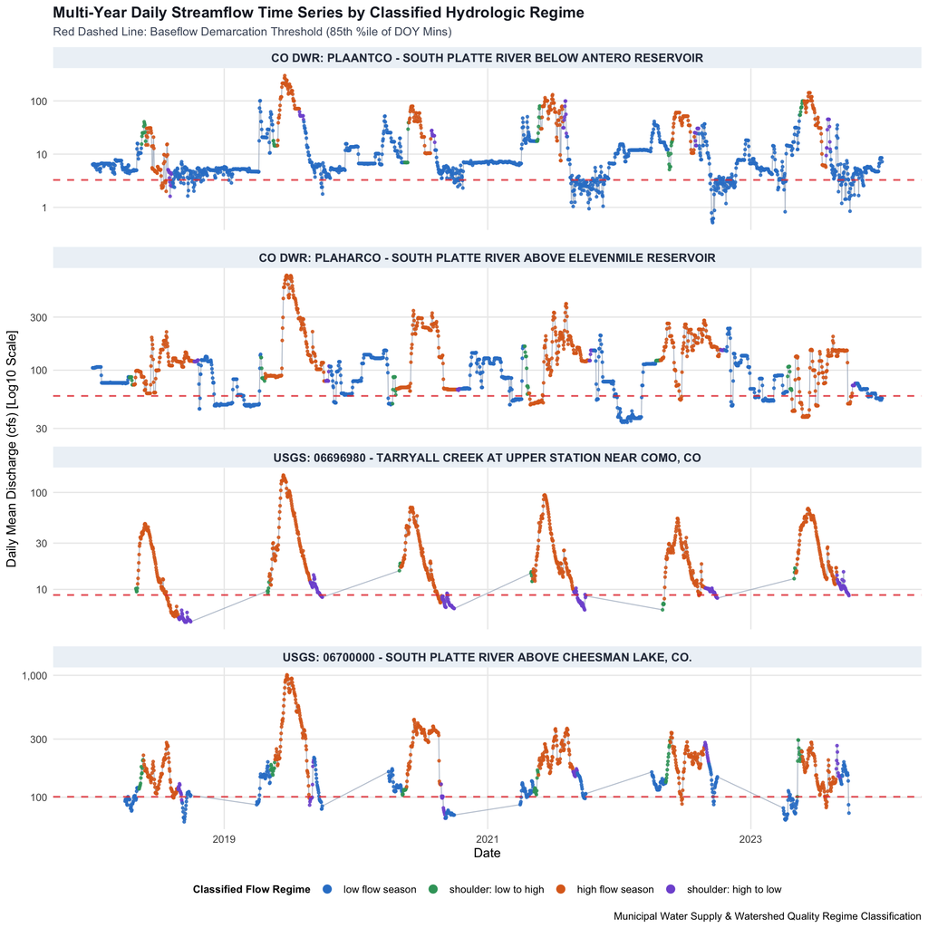

```r
plot_regime_timeseries(
  daily_classified = regime_diagnostics$daily_classified,
  year_range = c(2018, 2023)
)
```

## 5.3 Annual Regime Progression Calendar Matrices

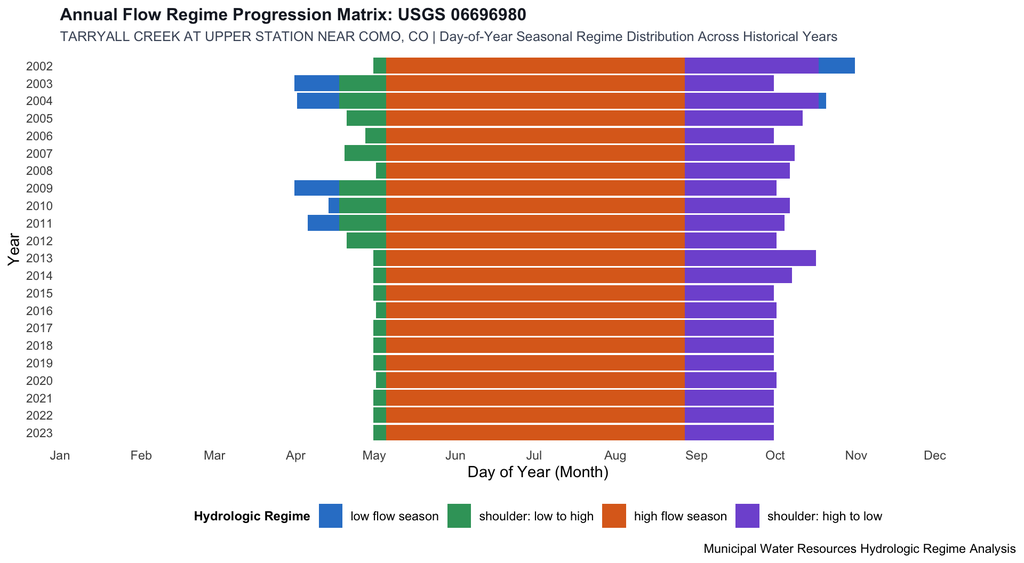

```r
plot_regime_annual_heatmap(regime_diagnostics$daily_classified, site_filter = "06696980")
```

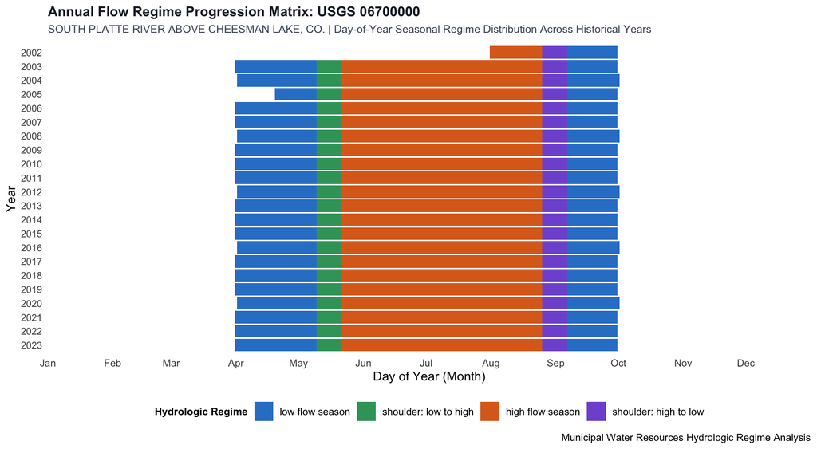

```r
plot_regime_annual_heatmap(regime_diagnostics$daily_classified, site_filter = "06700000")
```

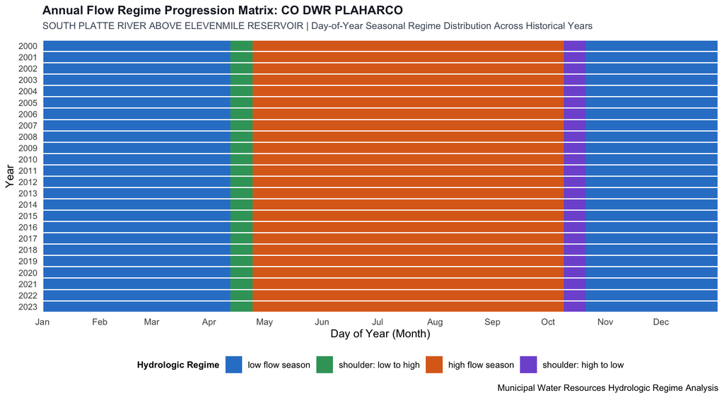

```r
plot_regime_annual_heatmap(regime_diagnostics$daily_classified, site_filter = "PLAHARCO")
```

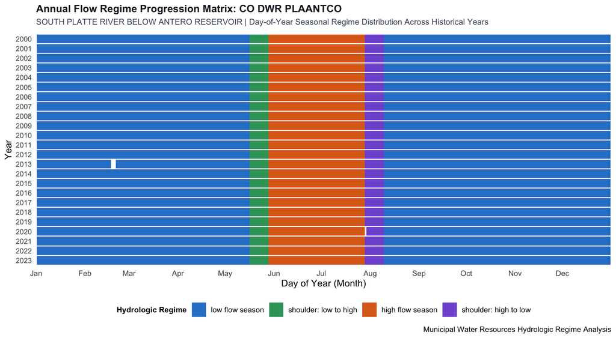

```r
plot_regime_annual_heatmap(regime_diagnostics$daily_classified, site_filter = "PLAANTCO")
```

# 6. Hydrologic Regime Breakdown & Statistical Summary

The table below summarizes the distribution of daily records, percentage of total time, and flow statistics across the four classified flow regimes:

**Table 5: Discharge Statistics by Flow Regime Phase**

| agency | site_id | station_name | flow_regime | Total Days | Min Flow (cfs) | 25th %ile (cfs) | Median Flow (cfs) | Mean Flow (cfs) | 75th %ile (cfs) | Max Flow (cfs) |
| --- | --- | --- | --- | --- | --- | --- | --- | --- | --- | --- |
| CO DWR | PLAANTCO | SOUTH PLATTE RIVER BELOW ANTERO RESERVOIR | low flow season | 6723 | 0.5 | 4.5 | 6.1 | 10.3 | 11.0 | 302.0 |
| CO DWR | PLAANTCO | SOUTH PLATTE RIVER BELOW ANTERO RESERVOIR | shoulder: low to high | 288 | 2.5 | 7.0 | 27.5 | 44.3 | 70.4 | 184.0 |
| CO DWR | PLAANTCO | SOUTH PLATTE RIVER BELOW ANTERO RESERVOIR | high flow season | 1464 | 1.4 | 10.4 | 46.1 | 63.6 | 86.0 | 436.1 |
| CO DWR | PLAANTCO | SOUTH PLATTE RIVER BELOW ANTERO RESERVOIR | shoulder: high to low | 287 | 1.6 | 7.0 | 23.0 | 42.3 | 48.0 | 305.0 |
| CO DWR | PLAHARCO | SOUTH PLATTE RIVER ABOVE ELEVENMILE RESERVOIR | low flow season | 4158 | 32.0 | 54.0 | 72.0 | 78.5 | 93.0 | 238.0 |
| CO DWR | PLAHARCO | SOUTH PLATTE RIVER ABOVE ELEVENMILE RESERVOIR | shoulder: low to high | 288 | 34.0 | 65.0 | 87.0 | 96.9 | 108.0 | 325.0 |
| CO DWR | PLAHARCO | SOUTH PLATTE RIVER ABOVE ELEVENMILE RESERVOIR | high flow season | 4032 | 33.0 | 87.0 | 140.0 | 163.1 | 203.0 | 1200.0 |
| CO DWR | PLAHARCO | SOUTH PLATTE RIVER ABOVE ELEVENMILE RESERVOIR | shoulder: high to low | 288 | 33.0 | 80.0 | 98.0 | 106.6 | 135.0 | 246.0 |
| USGS | 06696980 | TARRYALL CREEK AT UPPER STATION NEAR COMO, CO | low flow season | 83 | 3.1 | 3.8 | 4.3 | 4.6 | 5.4 | 7.6 |
| USGS | 06696980 | TARRYALL CREEK AT UPPER STATION NEAR COMO, CO | shoulder: low to high | 206 | 3.4 | 7.0 | 9.4 | 10.8 | 12.9 | 33.8 |
| USGS | 06696980 | TARRYALL CREEK AT UPPER STATION NEAR COMO, CO | high flow season | 2508 | 3.1 | 14.1 | 22.4 | 35.0 | 46.9 | 402.0 |
| USGS | 06696980 | TARRYALL CREEK AT UPPER STATION NEAR COMO, CO | shoulder: high to low | 844 | 2.9 | 7.1 | 9.2 | 10.0 | 11.3 | 68.0 |
| USGS | 06700000 | SOUTH PLATTE RIVER ABOVE CHEESMAN LAKE, CO. | low flow season | 1328 | 53.0 | 98.0 | 120.5 | 136.7 | 154.0 | 484.0 |
| USGS | 06700000 | SOUTH PLATTE RIVER ABOVE CHEESMAN LAKE, CO. | shoulder: low to high | 252 | 53.1 | 122.8 | 164.0 | 182.2 | 198.5 | 669.0 |
| USGS | 06700000 | SOUTH PLATTE RIVER ABOVE CHEESMAN LAKE, CO. | high flow season | 2041 | 68.7 | 170.0 | 245.0 | 305.6 | 366.0 | 2210.0 |
| USGS | 06700000 | SOUTH PLATTE RIVER ABOVE CHEESMAN LAKE, CO. | shoulder: high to low | 264 | 65.5 | 126.0 | 157.0 | 171.8 | 203.2 | 393.0 |

# 7. Interactive Daily Classification Table

Below is the complete interactive daily classification table. Users can search by date (e.g. `2023-06`), station ID (`06700000`), or regime name, sort by flow magnitude, or export the data for external analysis:

```r
table_export <- regime_diagnostics$daily_classified %>%
  transmute(
    Date = as.character(date),
    Agency = agency,
    `Site ID` = site_id,
    `Station Name` = station_name,
    DOY = doy,
    `Flow (cfs)` = round(flow_cfs, 2),
    `Demarcation Threshold (cfs)` = round(t_demarcation, 2),
    `Climatological Regime` = flow_regime,
    `Real-Time Dynamic Regime` = dynamic_regime,
    `Quality Flag` = if_else(is.na(qualifier), "-", qualifier)
  )

datatable(
  table_export,
  extensions = c("Buttons", "Scroller"),
  options = list(
    deferRender = TRUE,
    scrollY = 400,
    scroller = TRUE,
    dom = "Bfrtip",
    buttons = c("copy", "csv", "excel"),
    pageLength = 25,
    order = list(list(0, "desc"))
  ),
  filter = "top",
  rownames = FALSE,
  caption = "Table 6: Searchable Daily Streamflow Records & Regime Classifications (2000-2023)"
)
```

| Date | Agency | Site ID | Station Name | DOY | Flow (cfs) | Demarcation Threshold (cfs) | Climatological Regime | Real-Time Dynamic Regime | Quality Flag |
| --- | --- | --- | --- | --- | --- | --- | --- | --- | --- |
| 2000-01-01 | CO DWR | PLAANTCO | SOUTH PLATTE RIVER BELOW ANTERO RESERVOIR | 1 | 17 | 3.27 | low flow season | low flow season | A |
| 2000-01-01 | CO DWR | PLAHARCO | SOUTH PLATTE RIVER ABOVE ELEVENMILE RESERVOIR | 1 | 110 | 58.75 | low flow season | low flow season | A |
| 2000-01-02 | CO DWR | PLAANTCO | SOUTH PLATTE RIVER BELOW ANTERO RESERVOIR | 2 | 17 | 3.27 | low flow season | shoulder: low to high | A |
| 2000-01-02 | CO DWR | PLAHARCO | SOUTH PLATTE RIVER ABOVE ELEVENMILE RESERVOIR | 2 | 110 | 58.75 | low flow season | shoulder: low to high | A |
| 2000-01-03 | CO DWR | PLAANTCO | SOUTH PLATTE RIVER BELOW ANTERO RESERVOIR | 3 | 17 | 3.27 | low flow season | shoulder: low to high | A |
| 2000-01-03 | CO DWR | PLAHARCO | SOUTH PLATTE RIVER ABOVE ELEVENMILE RESERVOIR | 3 | 105 | 58.75 | low flow season | shoulder: high to low | A |
| 2000-01-04 | CO DWR | PLAANTCO | SOUTH PLATTE RIVER BELOW ANTERO RESERVOIR | 4 | 17 | 3.27 | low flow season | shoulder: low to high | A |
| 2000-01-04 | CO DWR | PLAHARCO | SOUTH PLATTE RIVER ABOVE ELEVENMILE RESERVOIR | 4 | 94 | 58.75 | low flow season | shoulder: high to low | A |
| 2000-01-05 | CO DWR | PLAANTCO | SOUTH PLATTE RIVER BELOW ANTERO RESERVOIR | 5 | 17 | 3.27 | low flow season | shoulder: low to high | A |
| 2000-01-05 | CO DWR | PLAHARCO | SOUTH PLATTE RIVER ABOVE ELEVENMILE RESERVOIR | 5 | 77 | 58.75 | low flow season | shoulder: high to low | A |

[output cut: 25044 more lines]